# Common Garden Design

## Intro

Goal: decide number of pops, maternal families, etc. Then planting design. Parameters: maximize number of pops, then number of maternal families. Plant 2000.

```r
library(tidyverse)
library(googlesheets4)
library(ggforce)

is.even <- function(x) x%%2 == 0
```

## get data on pops and families

```r
pops <- read_sheet("https://docs.google.com/spreadsheets/d/1dif9Y5hbkSa56Bgonj04-jXh8jNc6f13RBS6BPUf1IQ",
                   skip=1,
                   na=c("NA", ""),
                   col_types = c("ciiiccccc"),
                   .name_repair = "universal") %>%
  mutate(approx.number.seeds = as.integer(str_remove_all(approx.number.seeds,"[^0-9]")))
```

```
The googlesheets4 package is requesting access to your Google account.
Select a pre-authorised account or enter '0' to obtain a new token.
Press Esc/Ctrl + C to cancel.
```

```
1: jnmaloof@ucdavis.edu
```

```r
 1
```

```
Auto-refreshing stale OAuth token.
✔ Reading from Int Bio parents seed stock.
✔ Range 2:10000000.
```

```r
pops
```

| parent.pop | phylogroup | collection.year | maternal.families | approx.number.seeds | collection.priority. | on.climate.PCA. | JGI.DNA | notes |
| --- | --- | --- | --- | --- | --- | --- | --- | --- |
| YO11 | 1 | 2021 | 10 | 1000 | NA | Y | NA | NA |
| YO11 | 1 | 2019 | NA | NA | NA | Y | NA | unknown, Elena has? |
| YO11 | 1 | 2016 | 5 | 50 | NA | NA | NA | NA |
| HH | 1 | 2008 | 15 | 200 | yes | N | NA | seed too old? |
| YO1 | 1 | 2019 | 8 | 20 | NA | NA | Y | NA |
| YO4 | 1 | 2020 | 26 | 500 | NA | NA | NA | NA |
| YO4 | 1 | 2021 | 35 | 500 | NA | Y | NA | NA |
| YO7 | 1 | 2020 | 24 | 500 | NA | NA | NA | NA |
| YO7 | 1 | 2021 | 21 | 1000 | NA | Y | NA | NA |
| YO8 | 1 | 2019 | 18 | 50 | NA | NA | Y | NA |

[output cut: 38 more lines]

## filter to one entry per pop, etc

```r
pops.filtered <- pops %>% group_by(parent.pop) %>% slice_max(order_by=maternal.families) %>%
  filter(approx.number.seeds >= 100) %>%
  filter(!(parent.pop %in% c("HH", "RB"))) # old seed

pops.filtered %>% arrange(maternal.families)
```

| parent.pop | phylogroup | collection.year | maternal.families | approx.number.seeds | collection.priority. | on.climate.PCA. | JGI.DNA | notes |
| --- | --- | --- | --- | --- | --- | --- | --- | --- |
| WV | 8 | 2014 | 3 | 200 | yes | Y | NA | original envelope? |
| WR | 8 | 2016 | 4 | 200 | yes | N | NA | NA |
| LVTR1 | 9 | 2020 | 10 | 100 | yes | Y | NA | NA |
| YO11 | 1 | 2021 | 10 | 1000 | NA | Y | NA | NA |
| LV3 | 9 | 2020 | 11 | 500 | yes | Y | NA | NA |
| CP3 | 2 | 2018 | 15 | 200 | yes | Y | NA | NA |
| CC | 7 | 2018 | 18 | 500 | NA | Y | NA | NA |
| SQ2 | 3 | 2021 | 20 | 1000 | NA | Y | NA | NA |
| DPR | 5 | 2020 | 21 | 300 | yes | Y | NA | NA |
| FR | 7 | 2019 | 22 | 500 | yes | Y | NA | seeds were not present when started parent pops in october 2021; seeds appeared in bin recently |

[output cut: 13 more lines]

```r
sum(pops.filtered$maternal.families>=8)
```

```
[1] 21
```

```r
sum(pops.filtered$maternal.families>=15)
```

```
[1] 18
```

### Scenario 1:

Plant 21 pops * 8 families * 12 reps (= 2016 plants)

### Scenario 3:

__Note: after calculating above, Sarah found more mfs from WV, so:_

3 mfs from WR and 7 mfs from everyone else

total mfs = 3+7*22 = 157* 13 reps (= 2041 plants)

## Which pops?

This is the full (filtered) data sheet.

```r
pops.filtered %>% arrange(parent.pop) %>% write_csv("../output/Pops_for_2022_UCD.csv")
```

## planting grid

### go with plan 3

### Example plot for “60 in veg crop” bed.

Sarah says this is 100 cm of plantable width.

2041 plants. 1 block per rep, so 13 blocks each of 157 plants

157/4 = 39.25 with 4 columns this is 39.25 plants per column per block. Call it 40. But then two more buffers on each side, call it 44

Create grid

```r
stagger <- TRUE
buffer.blocks <- 2
buffer.rows <- 2 # on each edge of each block
exp.blocks <- 13
blocks <- LETTERS[1:(buffer.blocks+exp.blocks)]
columns <- 4 # per block
rows <- 44 # four of which are buffers
plants <- length(blocks) * columns * rows
bedwidth <- 100 # cm
furrow <- 52 #cm
size <- 30 # plant diameter
radius <- size/2
blankevery <- 2 # what is the spacing between blank beds?  (2 means every other; 3 means every third)
expandfactor <- blankevery/(blankevery-1)

plan3 <- expand_grid(block=blocks,
                     column=1:columns,
                     row=1:rows,
                     radius=radius)

plan3 <- plan3 %>%
  mutate(plantedcol=(match(block, LETTERS)-1)*4 + column,
         bedcol = floor((match(block, LETTERS)-1)*expandfactor + 1   ))

plan3
```

| block | column | row | radius | plantedcol | bedcol |
| --- | --- | --- | --- | --- | --- |
| A | 1 | 1 | 15 | 1 | 1 |
| A | 1 | 2 | 15 | 1 | 1 |
| A | 1 | 3 | 15 | 1 | 1 |
| A | 1 | 4 | 15 | 1 | 1 |
| A | 1 | 5 | 15 | 1 | 1 |
| A | 1 | 6 | 15 | 1 | 1 |
| A | 1 | 7 | 15 | 1 | 1 |
| A | 1 | 8 | 15 | 1 | 1 |
| A | 1 | 9 | 15 | 1 | 1 |
| A | 1 | 10 | 15 | 1 | 1 |

[output cut: 990 more lines]

add positions

```r
if (stagger) {
  ## first part needs to be updated for beds
  column_offset <- sqrt((2*radius)^2 - radius^2) # Pythagorean theorem for offset spacing
  plan3 <- plan3 %>%
    mutate(y_pos=ifelse(is.even(column),
                        row*size,
                        row*size-radius),
           x_pos=ifelse(column==1,
                        radius+(bedcol-1)*(bedwidth+furrow),
                        radius+(column-1)*column_offset+(bedcol-1)*(bedwidth+furrow)))
} else {
  plan3 <- plan3 %>%
    mutate(y_pos=row*size,
           x_pos=bedcol*(bedwidth+furrow))
}
plan3
```

| block | column | row | radius | plantedcol | bedcol | y_pos | x_pos |
| --- | --- | --- | --- | --- | --- | --- | --- |
| A | 1 | 1 | 15 | 1 | 1 | 15 | 15.00000 |
| A | 1 | 2 | 15 | 1 | 1 | 45 | 15.00000 |
| A | 1 | 3 | 15 | 1 | 1 | 75 | 15.00000 |
| A | 1 | 4 | 15 | 1 | 1 | 105 | 15.00000 |
| A | 1 | 5 | 15 | 1 | 1 | 135 | 15.00000 |
| A | 1 | 6 | 15 | 1 | 1 | 165 | 15.00000 |
| A | 1 | 7 | 15 | 1 | 1 | 195 | 15.00000 |
| A | 1 | 8 | 15 | 1 | 1 | 225 | 15.00000 |
| A | 1 | 9 | 15 | 1 | 1 | 255 | 15.00000 |
| A | 1 | 10 | 15 | 1 | 1 | 285 | 15.00000 |

[output cut: 990 more lines]

Plot it

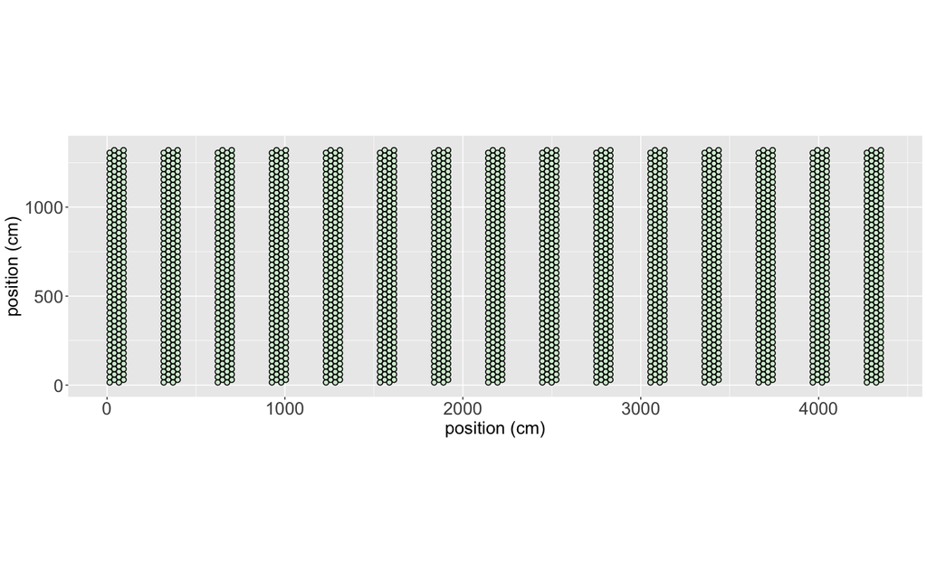

```r
#create block labels
# block.labels <- plan3 %>%
#   group_by(block) %>%
#   summarize(x_pos = mean(x_pos+block_x_offset), y_pos=max(y_pos*1.075))


plan3 %>% #filter(block=="A", row <6) %>%
  ggplot(aes(x0=x_pos, y0=y_pos, r=radius)) +
  geom_circle(fill="lightgreen", alpha=.25) +
  coord_equal() +
  #  geom_text(aes(x=x_pos, y=y_pos, label=block), size= 14, data = block.labels, inherit.aes = FALSE) +
  theme(axis.text = element_text(size=18), axis.title = element_text(size=18)) +
  xlab("position (cm)") + ylab("position (cm)")
```

```r
ggsave("../output/FieldPlan.jpeg", width = 10, height = 6)
```

Plot it in feet

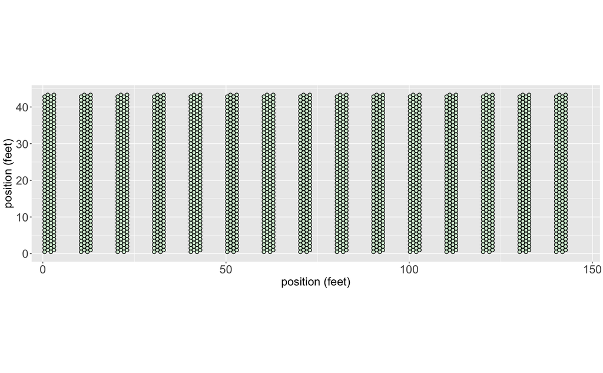

```r
#create block labels
# block.labels <- plan3 %>%
#   group_by(block) %>%
#   summarize(x_pos = mean(x_pos+block_x_offset), y_pos=max(y_pos*1.075))


plan3 %>% #filter(block=="A", row <6) %>%
  mutate(across(.cols=c(x_pos, y_pos, radius), ~ .x*0.0328084)) %>% # convert cm to feet
  ggplot(aes(x0=x_pos, y0=y_pos, r=radius)) +
  geom_circle(fill="lightgreen", alpha=.25) +
  coord_equal(xlim = c(4,145)) +
  #  geom_text(aes(x=x_pos, y=y_pos, label=block), size= 14, data = block.labels, inherit.aes = FALSE) +
  theme(axis.text = element_text(size=18), axis.title = element_text(size=18)) +
  xlab("position (feet)") + ylab("position (feet)")
```

```r
# ggsave("../output/FieldPlan.jpeg", width = 10, height = 6)
```

Output spacing for Black A to use as guide for cuting holes

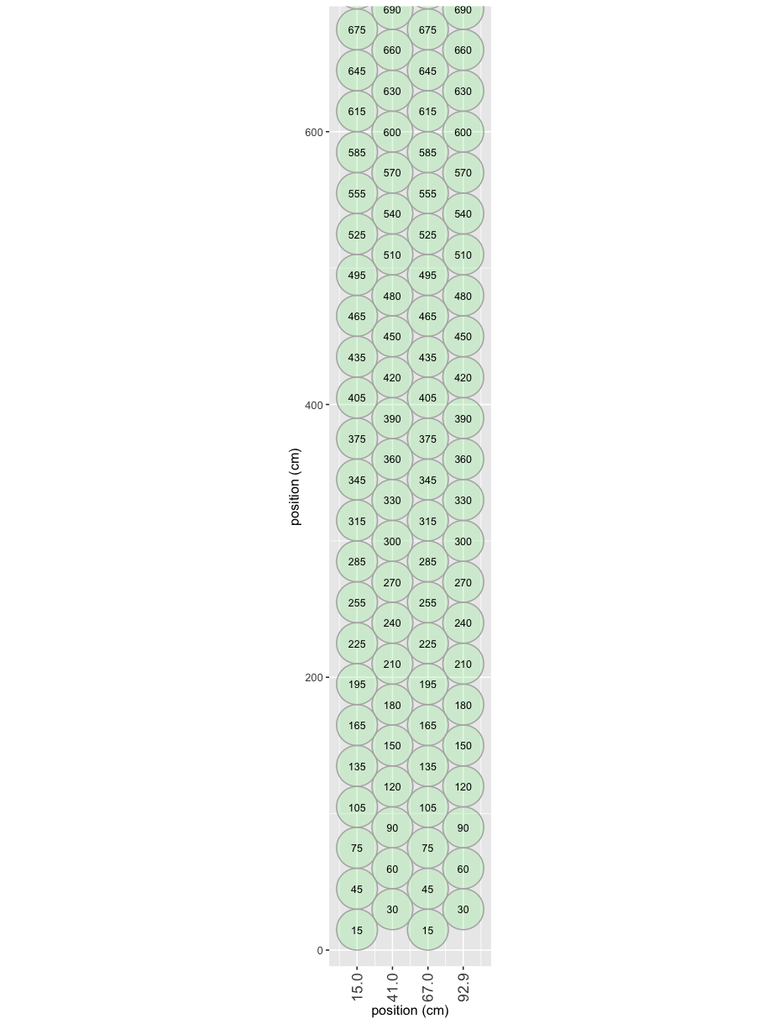

```r
x_labels <- plan3 %>% filter(block=="A") %>% pull(x_pos) %>% round(1) %>% unique()

plan3 %>% filter(block=="A") %>%
  ggplot(aes(x0=x_pos, y0=y_pos, r=radius, label=y_pos)) +
  geom_circle(fill="lightgreen", alpha=.25, color="grey70") +
  geom_text(aes(x=x_pos, y=y_pos), size=3) +
  scale_x_continuous(breaks = x_labels) +
  coord_equal(ylim = c(20,660)) +
  #  geom_text(aes(x=x_pos, y=y_pos, label=block), size= 14, data = block.labels, inherit.aes = FALSE) +
  theme(axis.text.x = element_text(angle=90, size=12, vjust = 0.5)) +
  xlab("position (cm)") + ylab("position (cm)")
```

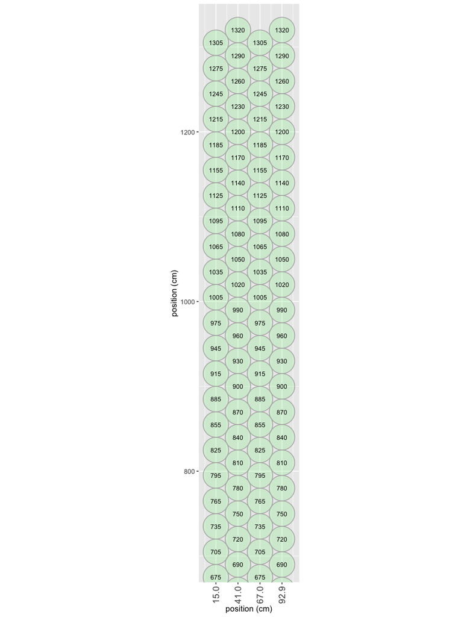

```r
ggsave("../output/spacing_guide_1.pdf", width = 8, height = 10.5)

plan3 %>% filter(block=="A") %>%
  ggplot(aes(x0=x_pos, y0=y_pos, r=radius, label=y_pos)) +
  geom_circle(fill="lightgreen", alpha=.25, color="grey70") +
  geom_text(aes(x=x_pos, y=y_pos), size=3) +
  scale_x_continuous(breaks = x_labels) +
  coord_equal(ylim = c(700,1320)) +
  #  geom_text(aes(x=x_pos, y=y_pos, label=block), size= 14, data = block.labels, inherit.aes = FALSE) +
  theme(axis.text.x = element_text(angle=90, size=12, vjust = 0.5)) +
  xlab("position (cm)") + ylab("position (cm)")
```

```r
ggsave("../output/spacing_guide_2.pdf", width = 8, height = 10.5)
```

Alternate, what if we stack blocks (NOT UPDATED)

```r
# # only offset x_positions (1 "row" of blocks)
# plan3 <- plan3 %>%
#   mutate(block_x_offset = as.integer(as.factor(block)) %% 7 -1,
#          block_x_offset = block_x_offset* (aisle + size + (columns-1)*column_offset)) %>%
#   mutate(block_y_offset = (as.integer(as.factor(block)) %/% 7)*-1+1 ,
#          block_y_offset = block_y_offset*size*rows+block_y_offset*aisle*1.5)
#
# #create block labels
# block.labels <- plan3 %>%
#   group_by(block) %>%
#   summarize(x_pos = mean(x_pos+block_x_offset), y_pos=max(block_y_offset + y_pos*1.075))
#
#
# plan3 %>% #filter(block=="A", row <6) %>%
#   ggplot(aes(x0=x_pos+block_x_offset, y0=y_pos+block_y_offset, r=radius)) +
#   geom_circle(fill="lightgreen", alpha=.25) +
#   coord_equal() +
#   geom_text(aes(x=x_pos, y=y_pos, label=block), size= 20, data = block.labels, inherit.aes = FALSE) +
#   theme(axis.text = element_text(size=16), axis.title = element_text(size=16)) +
#   xlab("position (cm)") + ylab("position (cm)")
```

## Assign Plants

```r
plants  <- read_sheet("https://docs.google.com/spreadsheets/d/1EaSA2QrlWAjFR35pedcvheQp3X7Agsla6pZtE2C1QJ4",
                      sheet="label making")
```

```
✔ Reading from Pops_for_2022_UCD.
✔ Range ''label making''.
✖ Request failed [429]. Retry 1 happens in 4 seconds ...
✖ Request failed [429]. Retry 2 happens in 11.6 seconds ...
✖ Request failed [429]. Retry 3 happens in 7.9 seconds ...
✖ Request failed [429]. Retry 4 happens in 45.8 seconds ...
```

```r
plants
```

| parent.pop | phylogroup | elevation.group | collection.year | mf | rep |
| --- | --- | --- | --- | --- | --- |
| CP2 | 2 | high | 2019 | 1 | 1 |
| CP2 | 2 | high | 2019 | 1 | 2 |
| CP2 | 2 | high | 2019 | 1 | 3 |
| CP2 | 2 | high | 2019 | 1 | 4 |
| CP2 | 2 | high | 2019 | 1 | 5 |
| CP2 | 2 | high | 2019 | 1 | 6 |
| CP2 | 2 | high | 2019 | 1 | 7 |
| CP2 | 2 | high | 2019 | 1 | 8 |
| CP2 | 2 | high | 2019 | 1 | 9 |
| CP2 | 2 | high | 2019 | 1 | 10 |

[output cut: 990 more lines]

set up row labels for sampling

```r
# because we have two buffer rows at the beginning and end, we start at row 3 and go to rows -2
rows.sample <- rep(3:(rows-2), times=c(rep(columns,rows-5), 1) )

#cols.sample <- rep(LETTERS[1:columns], times=c(rows, rep(rows-1, columns-1)))
```

Add block (easy because block ~= rep, but I am using letters for block and need to adjust for the buffer rows)

```r
plants <- plants %>% mutate(block=LETTERS[rep+(buffer.blocks/2)])
```

now add row and column positions:

```r
set.seed(092222) # so we get the same "randomization" each time we run this
plants <- plants %>%
  group_by(block) %>%
  mutate(row=sample(rows.sample)) %>%
  group_by(block, row) %>%
  mutate(column=sample(LETTERS[1:columns], size=n()))

plants %>% arrange(parent.pop, mf) # confirm different positions per block
```

| parent.pop | phylogroup | elevation.group | collection.year | mf | rep | block | row | column |
| --- | --- | --- | --- | --- | --- | --- | --- | --- |
| BH | 4 | low | 2021 | 1 | 1 | B | 26 | D |
| BH | 4 | low | 2021 | 1 | 2 | C | 39 | C |
| BH | 4 | low | 2021 | 1 | 3 | D | 30 | A |
| BH | 4 | low | 2021 | 1 | 4 | E | 10 | A |
| BH | 4 | low | 2021 | 1 | 5 | F | 30 | B |
| BH | 4 | low | 2021 | 1 | 6 | G | 35 | A |
| BH | 4 | low | 2021 | 1 | 7 | H | 28 | A |
| BH | 4 | low | 2021 | 1 | 8 | I | 41 | D |
| BH | 4 | low | 2021 | 1 | 9 | J | 11 | A |
| BH | 4 | low | 2021 | 1 | 10 | K | 10 | C |

[output cut: 990 more lines]

Fill in the blanks…

```r
plants <- plants %>% ungroup() %>%
  expand(block, row=1:rows, column) %>%
  left_join(plants) %>%
  mutate(parent.pop=ifelse(is.na(parent.pop), "buffer", parent.pop))
plants
```

| block | row | column | parent.pop | phylogroup | elevation.group | collection.year | mf | rep |
| --- | --- | --- | --- | --- | --- | --- | --- | --- |
| B | 1 | A | buffer | NA | NA | NA | NA | NA |
| B | 1 | B | buffer | NA | NA | NA | NA | NA |
| B | 1 | C | buffer | NA | NA | NA | NA | NA |
| B | 1 | D | buffer | NA | NA | NA | NA | NA |
| B | 2 | A | buffer | NA | NA | NA | NA | NA |
| B | 2 | B | buffer | NA | NA | NA | NA | NA |
| B | 2 | C | buffer | NA | NA | NA | NA | NA |
| B | 2 | D | buffer | NA | NA | NA | NA | NA |
| B | 3 | A | YO11 | 1 | high | 2021 | 5 | 1 |
| B | 3 | B | CP2 | 2 | high | 2019 | 1 | 1 |

[output cut: 990 more lines]

We have a total of 13 * 4 = 52 columns. 8 flats have a total of 56 columns.

```r
plants <- plants %>% ungroup() %>%
  mutate(ubercolumn = as.integer(factor(str_c(block, column))),
         flat = ifelse(row <= rows - buffer.rows, ((row - 1 ) %/% 14) + 1, NA), # row assignment for lat
         flat = flat + ((ubercolumn - 1) %/% 7) * 3,  # column assignments to flat (7 columns per flat)
         flat_row = ((row-1) %% 14) + 1,
         flat_column = LETTERS[((ubercolumn-1) %% 7) + 1])
plants
```

| block | row | column | parent.pop | phylogroup | elevation.group | collection.year | mf | rep | ubercolumn | flat | flat_row | flat_column |
| --- | --- | --- | --- | --- | --- | --- | --- | --- | --- | --- | --- | --- |
| B | 1 | A | buffer | NA | NA | NA | NA | NA | 1 | 1 | 1 | A |
| B | 1 | B | buffer | NA | NA | NA | NA | NA | 2 | 1 | 1 | B |
| B | 1 | C | buffer | NA | NA | NA | NA | NA | 3 | 1 | 1 | C |
| B | 1 | D | buffer | NA | NA | NA | NA | NA | 4 | 1 | 1 | D |
| B | 2 | A | buffer | NA | NA | NA | NA | NA | 1 | 1 | 2 | A |
| B | 2 | B | buffer | NA | NA | NA | NA | NA | 2 | 1 | 2 | B |
| B | 2 | C | buffer | NA | NA | NA | NA | NA | 3 | 1 | 2 | C |
| B | 2 | D | buffer | NA | NA | NA | NA | NA | 4 | 1 | 2 | D |
| B | 3 | A | YO11 | 1 | high | 2021 | 5 | 1 | 1 | 1 | 3 | A |
| B | 3 | B | CP2 | 2 | high | 2019 | 1 | 1 | 2 | 1 | 3 | B |

[output cut: 990 more lines]

```r
tail(plants)
```

| block | row | column | parent.pop | phylogroup | elevation.group | collection.year | mf | rep | ubercolumn | flat | flat_row | flat_column |
| --- | --- | --- | --- | --- | --- | --- | --- | --- | --- | --- | --- | --- |
| N | 43 | C | buffer | NA | NA | NA | NA | NA | 51 | NA | 1 | B |
| N | 43 | D | buffer | NA | NA | NA | NA | NA | 52 | NA | 1 | C |
| N | 44 | A | buffer | NA | NA | NA | NA | NA | 49 | NA | 2 | G |
| N | 44 | B | buffer | NA | NA | NA | NA | NA | 50 | NA | 2 | A |
| N | 44 | C | buffer | NA | NA | NA | NA | NA | 51 | NA | 2 | B |
| N | 44 | D | buffer | NA | NA | NA | NA | NA | 52 | NA | 2 | C |

Not using. Can use if we want flats to run the other way in the field.

```r
plants <- plants %>% ungroup() %>%
  mutate(ubercolumn = as.integer(factor(str_c(block, column))),
         flat = (ubercolumn + 6) %/% 7, # column assignments to flat (7 columns per flat)
         flat = flat + ((row-1) %/% 14)*8, # adjust for row (14 rows per flat, 8 flats per row of flats)
         flat_row = ((row-1) %% 14) + 1,
         flat_column = LETTERS[((ubercolumn-1) %% 7) + 1)]

plants

tail(plants)
```

plot flatmaps

```r
flat.plots <- map(unique(plants$flat), function(f) {

  plants.flat <- plants %>% filter(flat==f) %>%
    mutate(label=ifelse(is.na(mf),
                        str_c(parent.pop, "\n", block, "-", row, column),
                        str_c(parent.pop, "-", mf, "-r", rep, "\n", block, "-", row, column)))

  row.labels <- plants.flat %>% pull(row) %>% unique() %>% sort()
  col.labels <- plants.flat %>% pull(ubercolumn) %>% unique() %>% sort()

  plants.flat %>%  ggplot(aes(x=ubercolumn, y=row, x0=ubercolumn, y0 = row, label=label)) +
    geom_tile(fill="white", color="black") +
    coord_equal(expand = FALSE) +
    geom_text(size=3) +
    scale_y_reverse(labels=row.labels, breaks=row.labels) +
    scale_x_continuous(labels=col.labels, breaks=col.labels) +
    ggtitle(str_c("Flat ", f))
}
)
```

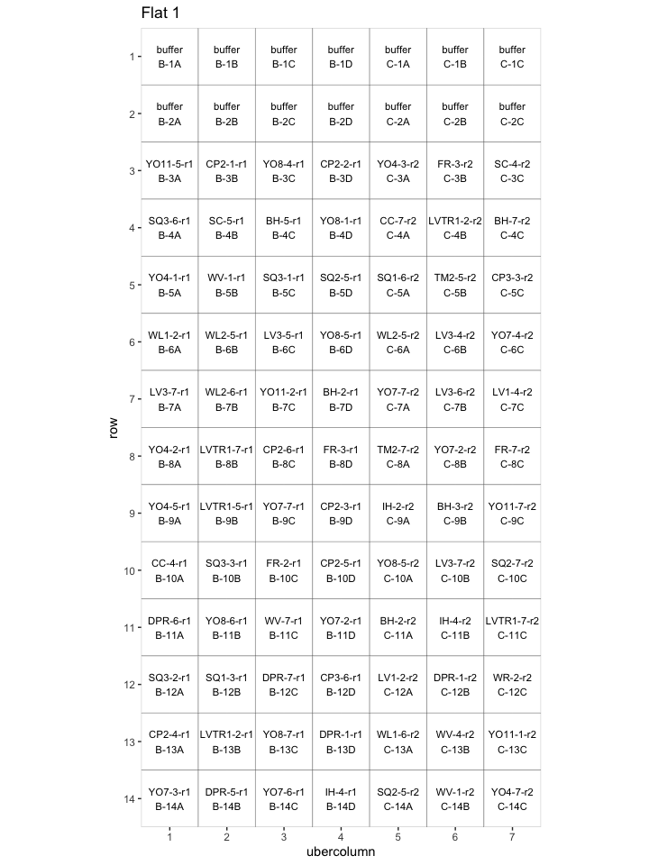

```r
flat.plots[[1]]
```

```r
pdf(file="../output/flatmaps.pdf", width=7.5, height = 10)
walk(flat.plots, print)
dev.off()
```

```r
plants %>% arrange(parent.pop, mf, rep) %>%
  select(parent.pop, mf, rep, flat, flat_row, flat_column, everything() ) %>% write_sheet("https://docs.google.com/spreadsheets/d/1EaSA2QrlWAjFR35pedcvheQp3X7Agsla6pZtE2C1QJ4",
                                                        sheet="Flat and Block map")
```

```
✔ Writing to Pops_for_2022_UCD.
✔ Writing to sheet Flat and Block map.
```

## combine flat map and field map

Plot with flats super-imposed

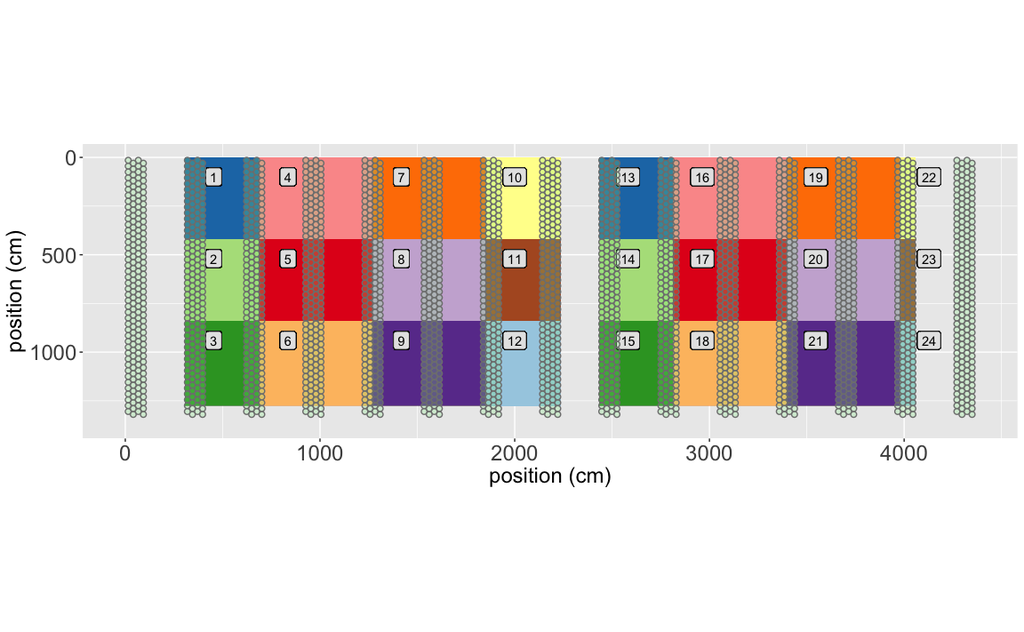

```r
plan3_flats <- plan3 %>%
  mutate(column=LETTERS[column]) %>%
  full_join(plants)
flat_coords <- plan3_flats %>%
  filter(!is.na(flat)) %>%
  group_by(flat) %>%
  summarize(
    xmin=min(x_pos)-radius,
    xmax=max(x_pos)+radius,
    ymin=min(y_pos)-radius,
    ymax=max(y_pos)+radius
  )
field.flat.plot <- flat_coords %>%
  ggplot(aes(xmin=xmin, xmax=xmax, ymin=ymin, ymax=ymax, fill=as.factor(flat %% 12))) +
  geom_rect() +
  scale_fill_brewer(palette = "Paired", guide="none") +
  geom_label(aes(x=xmin, y=ymin, label=flat), nudge_x = 150, nudge_y = -100, fill="grey90") +
  coord_equal() +
  scale_y_reverse()

field.flat.plot +
  geom_circle(data = plan3_flats, aes(x0=x_pos, y0=y_pos, r=radius), fill="lightgreen", color="grey50", alpha=.25, inherit.aes = FALSE) +
  #  geom_text(aes(x=x_pos, y=y_pos, label=block), size= 14, data = block.labels, inherit.aes = FALSE) +
  theme(axis.text = element_text(size=18), axis.title = element_text(size=18)) +
  xlab("position (cm)") + ylab("position (cm)")
```

```r
 ggsave("../output/FieldPlan_with_flats.jpeg", width = 10, height = 6)
```